# Manuscript submission code

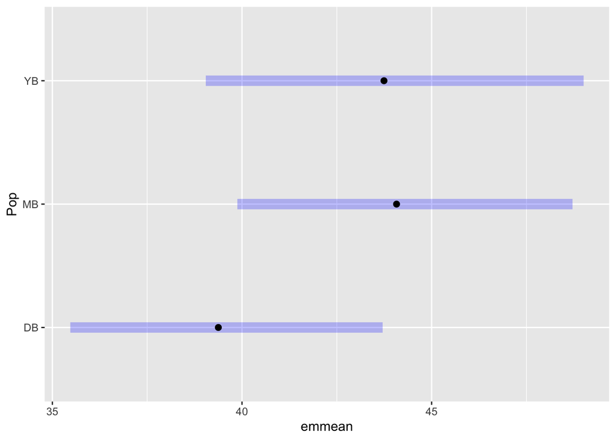

```r
estimates <- emmeans(dev_time_nb, "Pop", type  = "response", data = dev_time)

plot(estimates)
```

```r
estimates
```

```
##  Pop response   SE  df asymp.LCL asymp.UCL
##  DB      39.4 2.10 Inf      35.5      43.7
##  MB      44.1 2.25 Inf      39.9      48.7
##  YB      43.7 2.54 Inf      39.0      49.0
##
## Confidence level used: 0.95
## Intervals are back-transformed from the log scale
```

Create data frame of model estimates

```r
est <- c(39.4, 44.1, 43.7)
err_high <- c(43.7, 48.7, 49.0)
err_low <- c(35.5, 39.9, 39.0)

development_time <- data.frame(Population = site, Estimate = est, Error_high = err_high, Error_low = err_low)

development_time
```

```
##   Population Estimate Error_high Error_low
## 1         DB     39.4       43.7      35.5
## 2         MB     44.1       48.7      39.9
## 3         YB     43.7       49.0      39.0
```

Plot development time across populations

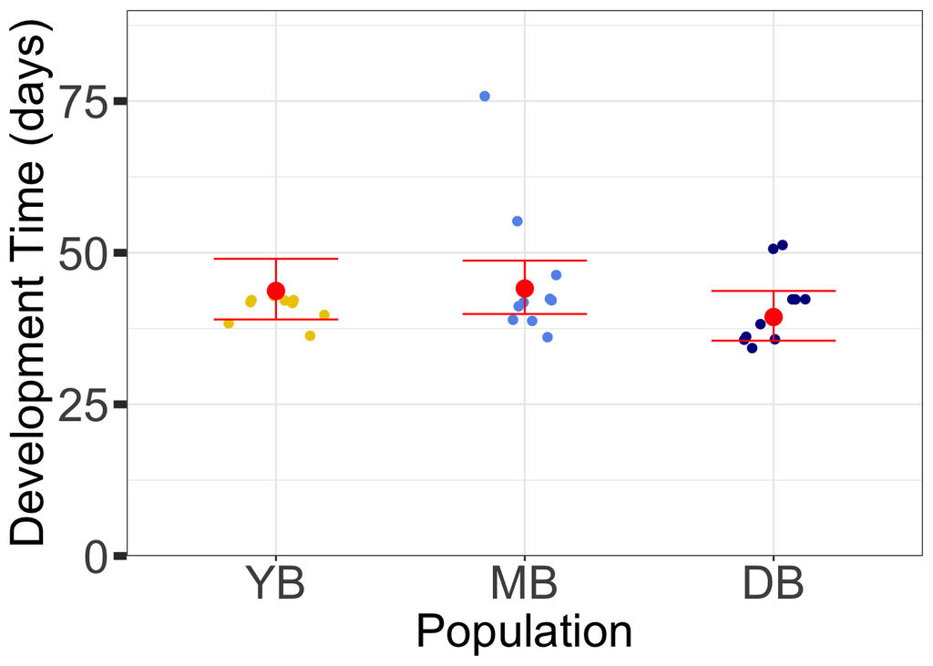

```r
ggplot(dev_time, aes(x = Pop, y = Time, color = Pop)) +
  geom_jitter(aes(x = Pop, y = Time), position=position_jitter(w=0.2), size = 2) +
  scale_color_manual(values = c("gold2", "cornflowerblue","darkblue")) +
  geom_point(data = development_time, aes(x = Population, y = Estimate), size = 4,  color = "red") +
  geom_errorbar(data = development_time, aes(x = Population, y = Estimate, ymin = Error_low, ymax = Error_high), color = "red", width = 0.5) +
  theme_bw() +
  theme(legend.position = "none",
        axis.title = element_text(size=25),
        axis.text = element_text(size=25),
        axis.ticks.y = element_line(linewidth = 2),
        axis.ticks.length.y = unit(0.25, "cm")) +
  scale_y_continuous(name = "Development Time (days)", expand = c(0, 0), limits = c(0, 90)) +
  xlab("Population") -> dev_time_plot

dev_time_plot$data$Pop <- factor(dev_time_plot$data$Pop, levels=neworder)

dev_time_plot
```

### Fecundity

Import data

```r
fecundity <- read.csv("/Users/keiramonuki/Documents/Sanford\ Lab/snail_tank_experiment/fecundity_updated_new.csv")

head(fecundity)
```

```
##       ID Pop Treatment Breeding_pair Num_capsules Num_hatchling_avg Fecundity
## 1 DB_H23  DB         H            23          335           44.0000 14740.000
## 2  MB_H7  MB         H             7          258           25.6667  6622.009
## 3  YB_H9  YB         H             9          235           32.0000  7520.000
## 4 MB_H20  MB         H            20          206           18.3333  3776.660
## 5  YB_H2  YB         H             2          238           31.0000  7378.000
## 6  DB_H4  DB         H             4          139           38.6667  5374.671
##   Avg_Size
## 1    30.10
## 2    23.65
## 3    19.40
## 4    18.70
## 5    21.70
## 6    21.30
```

Remove data from cold treatment and from RP population (not enough data for either)

```r
fecundity %>%
  filter(Treatment == "H") %>%
  filter(Pop != "RP") %>%
  filter(ID != "DB_H23")-> fecundity

head(fecundity)
```

```
##       ID Pop Treatment Breeding_pair Num_capsules Num_hatchling_avg Fecundity
## 1  MB_H7  MB         H             7          258           25.6667  6622.009
## 2  YB_H9  YB         H             9          235           32.0000  7520.000
## 3 MB_H20  MB         H            20          206           18.3333  3776.660
## 4  YB_H2  YB         H             2          238           31.0000  7378.000
## 5  DB_H4  DB         H             4          139           38.6667  5374.671
## 6  MB_H2  MB         H             2           52           61.5000  3198.000
##   Avg_Size
## 1    23.65
## 2    19.40
## 3    18.70
## 4    21.70
## 5    21.30
## 6    18.40
```

Check raw data distribution, including mean and standard deviation

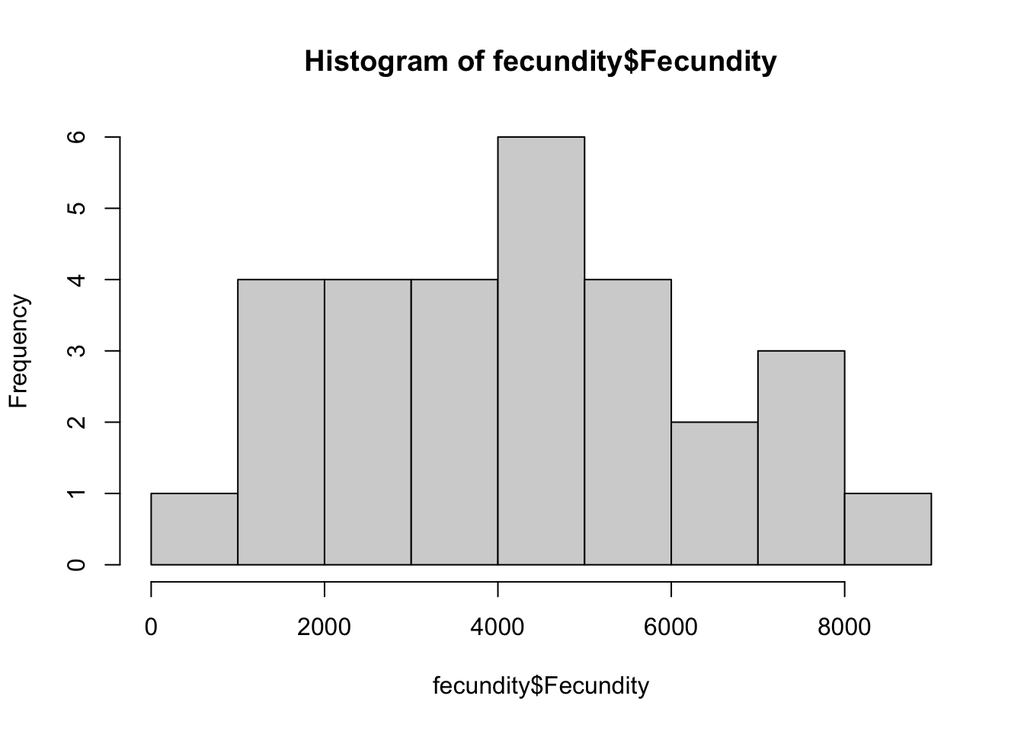

```r
hist(fecundity$Fecundity)
```

```r
mean(fecundity$Fecundity)
```

```
## [1] 4314.706
```

```r
sd(fecundity$Fecundity)
```

```
## [1] 2018.388
```

Run a GLMM with a Gamma distribution and log link function, and calculate AIC values

```r
fecundity_gm <- glm(Fecundity ~ Avg_Size + Pop, family = Gamma(link = log), data = fecundity)

summary(fecundity_gm)
```

```
##
## Call:
## glm(formula = Fecundity ~ Avg_Size + Pop, family = Gamma(link = log),
##     data = fecundity)
##
## Coefficients:
##             Estimate Std. Error t value Pr(>|t|)
## (Intercept)  8.98095    0.46403  19.354   <2e-16 ***
## Avg_Size    -0.04124    0.02067  -1.995   0.0570 .
## PopMB        0.08176    0.21315   0.384   0.7045
## PopYB        0.52235    0.20903   2.499   0.0194 *
## ---
## Signif. codes:  0 '***' 0.001 '**' 0.01 '*' 0.05 '.' 0.1 ' ' 1
##
## (Dispersion parameter for Gamma family taken to be 0.2056587)
##
##     Null deviance: 7.7404  on 28  degrees of freedom
## Residual deviance: 5.6270  on 25  degrees of freedom
## AIC: 523.39
##
## Number of Fisher Scoring iterations: 5
```

```r
anova(fecundity_gm)
```

```
## Analysis of Deviance Table
##
## Model: Gamma, link: log
##
## Response: Fecundity
##
## Terms added sequentially (first to last)
##
##
##          Df Deviance Resid. Df Resid. Dev      F  Pr(>F)
## NULL                        28     7.7404
## Avg_Size  1   0.5772        27     7.1632 2.8066 0.10634
## Pop       2   1.5362        25     5.6270 3.7347 0.03809 *
## ---
## Signif. codes:  0 '***' 0.001 '**' 0.01 '*' 0.05 '.' 0.1 ' ' 1
```

```r
Anova(fecundity_gm)
```

```
## Analysis of Deviance Table (Type II tests)
##
## Response: Fecundity
##          LR Chisq Df Pr(>Chisq)
## Avg_Size   4.6440  1    0.03116 *
## Pop        7.4695  2    0.02388 *
## ---
## Signif. codes:  0 '***' 0.001 '**' 0.01 '*' 0.05 '.' 0.1 ' ' 1
```

```r
AIC(fecundity_gm)
```

```
## [1] 523.3905
```

```r
AICc(fecundity_gm)
```

```
## [1] 525.9992
```

Back-transform model estimates to plot on top of the raw data scatter

```r
emmeans(fecundity_gm, "Pop", type  = "response", data = fecundity)
```

```
##  Pop response  SE df lower.CL upper.CL
##  DB      3378 512 25     2473     4615
##  MB      3666 541 25     2705     4969
##  YB      5695 830 25     4218     7690
##
## Confidence level used: 0.95
## Intervals are back-transformed from the log scale
```

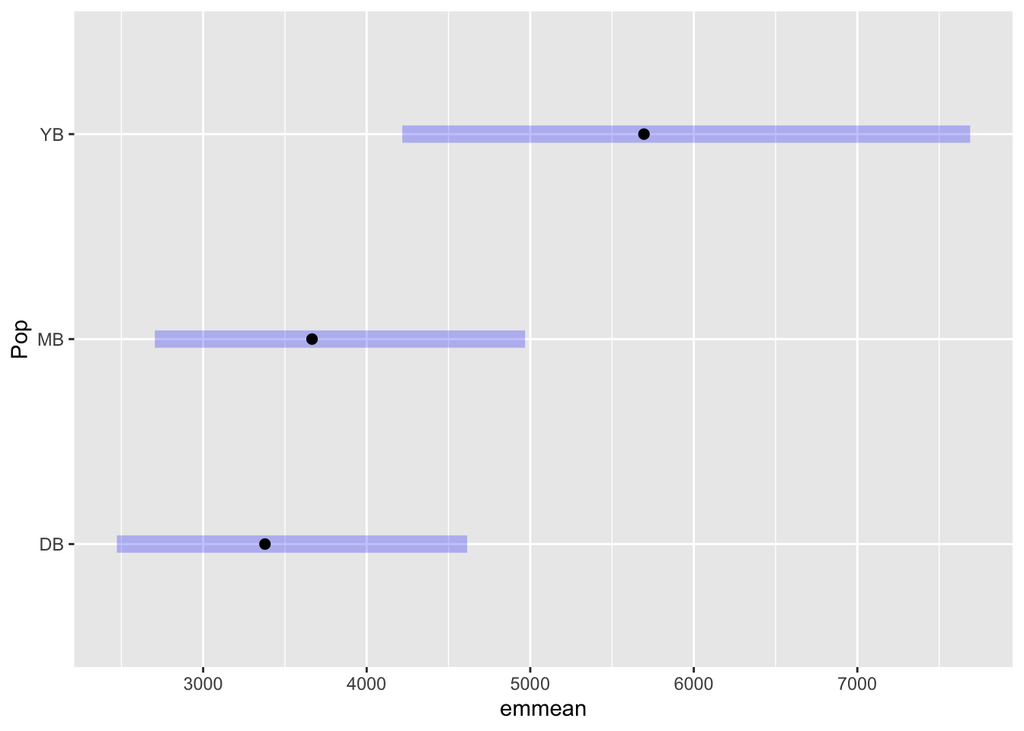

```r
estimates <- emmeans(fecundity_gm, "Pop", type  = "response", data = fecundity)

plot(estimates)
```

```r
estimates
```

```
##  Pop response  SE df lower.CL upper.CL
##  DB      3378 512 25     2473     4615
##  MB      3666 541 25     2705     4969
##  YB      5695 830 25     4218     7690
##
## Confidence level used: 0.95
## Intervals are back-transformed from the log scale
```

Create data frame of the model estimates

```r
est <- c(3378, 3666, 5695)
err_high <- c(4615, 4969, 7690)
err_low <- c(2473, 2705, 4218)

fecund <- data.frame(Population = site, Estimate = est, Error_high = err_high, Error_low = err_low)

fecund
```

```
##   Population Estimate Error_high Error_low
## 1         DB     3378       4615      2473
## 2         MB     3666       4969      2705
## 3         YB     5695       7690      4218
```

Plot fecundity across populations

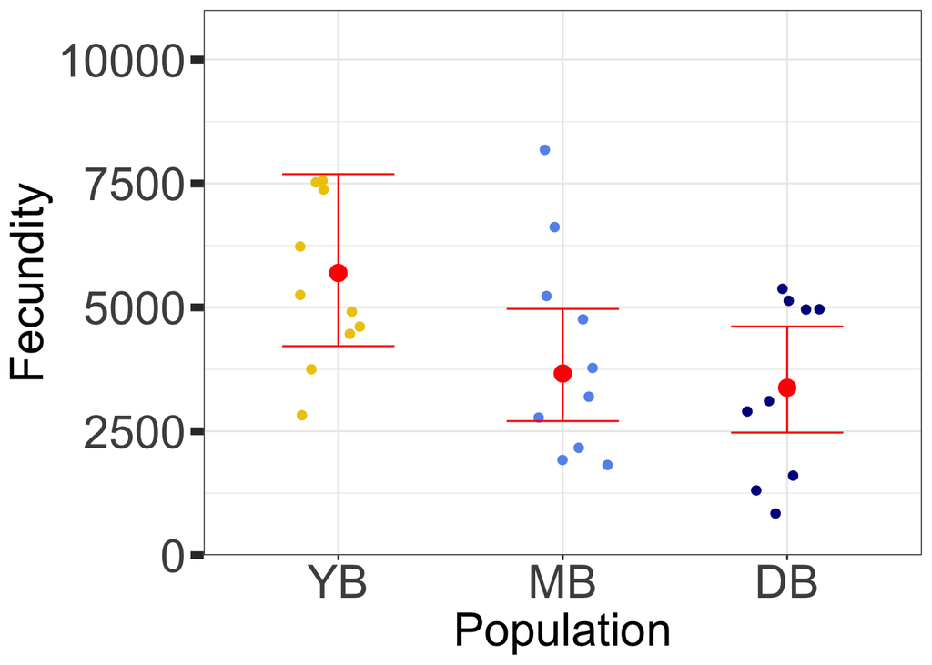

```r
ggplot(fecundity, aes(x = Pop, y = Fecundity, color = Pop)) +
  geom_jitter(aes(x = Pop, y = Fecundity), position=position_jitter(w=0.2), size = 2) +
  scale_color_manual(values = c("gold2", "cornflowerblue","darkblue")) +
  geom_point(data = fecund, aes(x = Population, y = Estimate), size = 4,  color = "red") +
  geom_errorbar(data = fecund, aes(x = Population, y = Estimate, ymin = Error_low, ymax = Error_high), color = "red", width = 0.5) +
  theme_bw() +
  theme(legend.position = "none",
        axis.title = element_text(size=25),
        axis.text = element_text(size=25),
        axis.ticks.y = element_line(linewidth = 2),
        axis.ticks.length.y = unit(0.25, "cm")) +
  scale_y_continuous(name = "Fecundity", expand = c(0,0), limits = c(0,11000)) +
  xlab("Population") -> fecund_plot

fecund_plot$data$Pop <- factor(fecund_plot$data$Pop, levels=neworder)

fecund_plot
```

Pairiwse comparisons using the emmeans package and Tukey adjustments

```r
em <- emmeans(fecundity_gm, "Pop", data = fecundity)
contrast(em, "pairwise", adjust = "Tukey")
```

```
##  contrast estimate    SE df t.ratio p.value
##  DB - MB   -0.0818 0.213 25  -0.384  0.9223
##  DB - YB   -0.5224 0.209 25  -2.499  0.0491
##  MB - YB   -0.4406 0.212 25  -2.079  0.1147
##
## Results are given on the log (not the response) scale.
## P value adjustment: tukey method for comparing a family of 3 estimates
```

### Hatchling Size

Import data

```r
hatchling_size <- read.csv("/Users/keiramonuki/Documents/Sanford\ Lab/snail_tank_experiment/hatchling_size_new.csv")

head(hatchling_size)
```

```
##          ID Pop Treatment Breeding_pair Capsule_ID Hatch_ID Hatch_size Avg_Size
## 1 YB_H9_4_5  YB         H             9          4        5      0.677     19.4
## 2 YB_H9_4_4  YB         H             9          4        4      0.596     19.4
## 3 YB_H9_4_3  YB         H             9          4        3      0.636     19.4
## 4 YB_H9_4_2  YB         H             9          4        2      0.652     19.4
## 5 YB_H9_4_1  YB         H             9          4        1      0.644     19.4
## 6 YB_H9_2_5  YB         H             9          2        5      0.595     19.4
```

Remove data from cold treatment and from RP population (not enough data for either)

```r
hatchling_size %>%
  filter(Treatment == "H") %>%
  filter(Pop != "RP") %>%
  filter (Breeding_pair != "23")-> hatchling_size

head(hatchling_size)
```

```
##          ID Pop Treatment Breeding_pair Capsule_ID Hatch_ID Hatch_size Avg_Size
## 1 YB_H9_4_5  YB         H             9          4        5      0.677     19.4
## 2 YB_H9_4_4  YB         H             9          4        4      0.596     19.4
## 3 YB_H9_4_3  YB         H             9          4        3      0.636     19.4
## 4 YB_H9_4_2  YB         H             9          4        2      0.652     19.4
## 5 YB_H9_4_1  YB         H             9          4        1      0.644     19.4
## 6 YB_H9_2_5  YB         H             9          2        5      0.595     19.4
```

Check raw data distribution, including mean and standard deviation

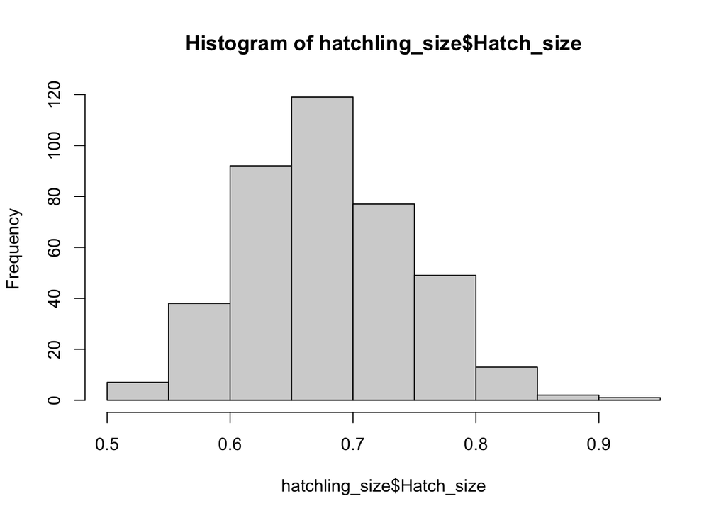

```r
hist(hatchling_size$Hatch_size)
```

```r
mean(hatchling_size$Hatch_size)
```

```
## [1] 0.6809523
```

```r
sd(hatchling_size$Hatch_size)
```

```
## [1] 0.06606809
```

Run a GLMM with a Gamma distribution and log link function, and calculate AIC values

```r
hatch_size_gm <-
  glm(Hatch_size ~ Avg_Size + Pop + (1 | Breeding_pair/Capsule_ID), family = Gamma(link = "log"), data = hatchling_size)

summary(hatch_size_gm)
```

```
##
## Call:
## glm(formula = Hatch_size ~ Avg_Size + Pop + (1 | Breeding_pair/Capsule_ID),
##     family = Gamma(link = "log"), data = hatchling_size)
##
## Coefficients: (1 not defined because of singularities)
##                                   Estimate Std. Error t value Pr(>|t|)
## (Intercept)                      -0.405269   0.064336  -6.299 8.00e-10 ***
## Avg_Size                          0.002571   0.002879   0.893 0.372443
## PopMB                            -0.050458   0.012028  -4.195 3.37e-05 ***
## PopYB                            -0.046382   0.013546  -3.424 0.000682 ***
## 1 | Breeding_pair/Capsule_IDTRUE        NA         NA      NA       NA
## ---
## Signif. codes:  0 '***' 0.001 '**' 0.01 '*' 0.05 '.' 0.1 ' ' 1
##
## (Dispersion parameter for Gamma family taken to be 0.008941854)
##
##     Null deviance: 3.7245  on 397  degrees of freedom
## Residual deviance: 3.4969  on 394  degrees of freedom
## AIC: -1053.9
##
## Number of Fisher Scoring iterations: 4
```

```r
anova(hatch_size_gm)
```

```
## Analysis of Deviance Table
##
## Model: Gamma, link: log
##
## Response: Hatch_size
##
## Terms added sequentially (first to last)
##
##
##                              Df Deviance Resid. Df Resid. Dev       F    Pr(>F)
## NULL                                           397     3.7245
## Avg_Size                      1 0.041709       396     3.6828  4.6645    0.0314
## Pop                           2 0.185868       394     3.4969 10.3932 3.993e-05
## 1 | Breeding_pair/Capsule_ID  0 0.000000       394     3.4969
##
## NULL
## Avg_Size                     *
## Pop                          ***
## 1 | Breeding_pair/Capsule_ID
## ---
## Signif. codes:  0 '***' 0.001 '**' 0.01 '*' 0.05 '.' 0.1 ' ' 1
```

```r
Anova(hatch_size_gm)
```

```
## Analysis of Deviance Table (Type II tests)
##
## Response: Hatch_size
##                              LR Chisq Df Pr(>Chisq)
## Avg_Size                       0.7846  1     0.3758
## Pop                           20.7863  2  3.064e-05 ***
## 1 | Breeding_pair/Capsule_ID           0
## ---
## Signif. codes:  0 '***' 0.001 '**' 0.01 '*' 0.05 '.' 0.1 ' ' 1
```

```r
AIC(hatch_size_gm)
```

```
## [1] -1053.898
```

```r
AICc(hatch_size_gm)
```

```
## [1] -1053.745
```

Back-transform model estimates to plot on top of the raw data scatter

```r
emmeans(hatch_size_gm, "Pop", type  = "response", data = hatchling_size)
```

```
##  Pop response      SE  df lower.CL upper.CL
##  DB     0.704 0.00638 394    0.692    0.717
##  MB     0.670 0.00587 394    0.658    0.681
##  YB     0.672 0.00598 394    0.661    0.684
##
## Confidence level used: 0.95
## Intervals are back-transformed from the log scale
```

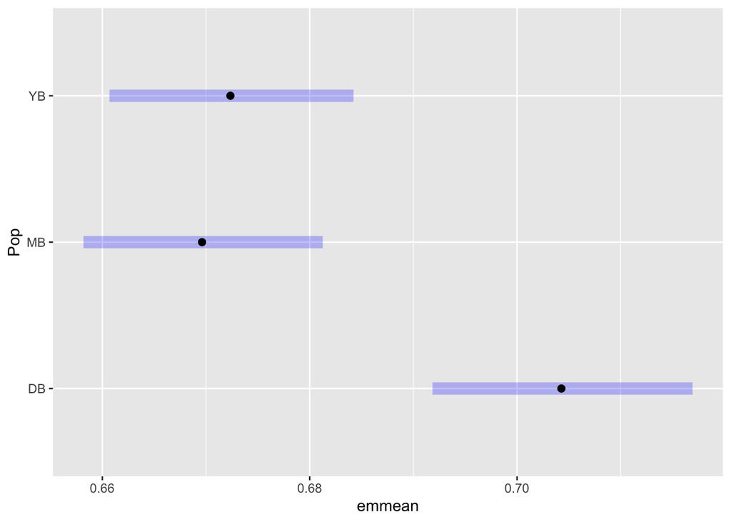

```r
estimates <- emmeans(hatch_size_gm, "Pop", type  = "response", data = hatchling_size)

plot(estimates)
```

```r
estimates
```

```
##  Pop response      SE  df lower.CL upper.CL
##  DB     0.704 0.00638 394    0.692    0.717
##  MB     0.670 0.00587 394    0.658    0.681
##  YB     0.672 0.00598 394    0.661    0.684
##
## Confidence level used: 0.95
## Intervals are back-transformed from the log scale
```

Create data frame of model estimates

```r
est <- c(0.704, 0.670, 0.672)
err_high <- c(0.717, 0.681, 0.684)
err_low <- c(0.692, 0.658, 0.661)

hatch_size <- data.frame(Pop = site, Estimate = est, Error_high = err_high, Error_low = err_low)
hatch_size
```

```
##   Pop Estimate Error_high Error_low
## 1  DB    0.704      0.717     0.692
## 2  MB    0.670      0.681     0.658
## 3  YB    0.672      0.684     0.661
```

Plot hatchling size across populations

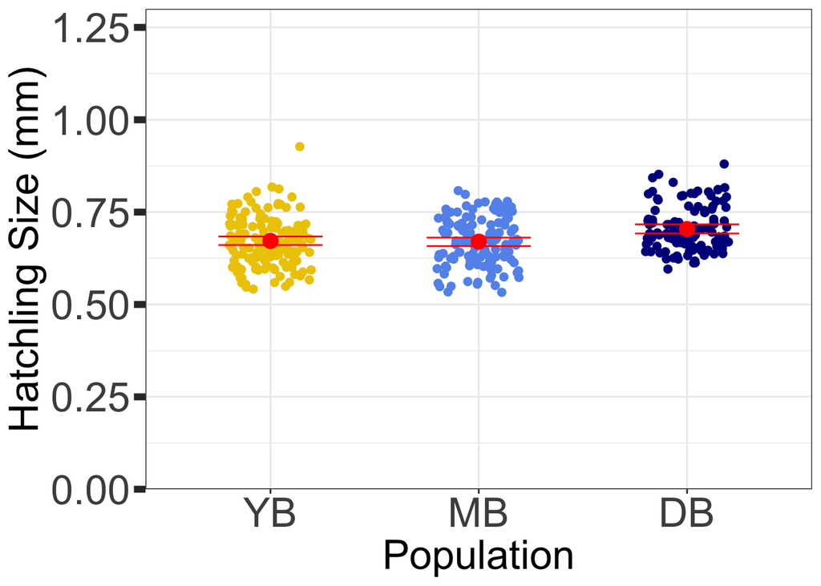

```r
ggplot(hatchling_size, aes(x = Pop, y = Hatch_size, color = Pop)) +
  geom_jitter(aes(x = Pop, y = Hatch_size), position=position_jitter(w=0.2), size = 2) +
  scale_color_manual(values = c("gold2", "cornflowerblue","darkblue")) +
  geom_point(data = hatch_size, aes(x = Pop, y = Estimate), size = 4,  color = "red") +
  geom_errorbar(data = hatch_size, aes(x = Pop, y = Estimate, ymin = Error_low, ymax = Error_high), color = "red", width = 0.5) +
  theme_bw() +
  theme(legend.position = "none",
        axis.title = element_text(size=25),
        axis.text = element_text(size=25),
        axis.ticks.y = element_line(linewidth = 2),
        axis.ticks.length.y = unit(0.25, "cm")) +
  scale_y_continuous(name = "Hatchling Size (mm)", expand = c(0,0), limits = c(0,1.3)) +
  xlab("Population") -> hatch_size_plot


hatch_size_plot$data$Pop <- factor(hatch_size_plot$data$Pop, levels=neworder)

hatch_size_plot
```

Calculate pairwise comparisons using the emmeans package and Tukey adjustments

```r
em <- emmeans(hatch_size_gm, "Pop", data = hatchling_size)
contrast(em, "pairwise", adjust = "Tukey")
```

```
##  contrast estimate     SE  df t.ratio p.value
##  DB - MB   0.05046 0.0120 394   4.195  0.0001
##  DB - YB   0.04638 0.0135 394   3.424  0.0020
##  MB - YB  -0.00408 0.0135 394  -0.303  0.9507
##
## Results are given on the log (not the response) scale.
## P value adjustment: tukey method for comparing a family of 3 estimates
```

Plot model resiuals to assess model fit

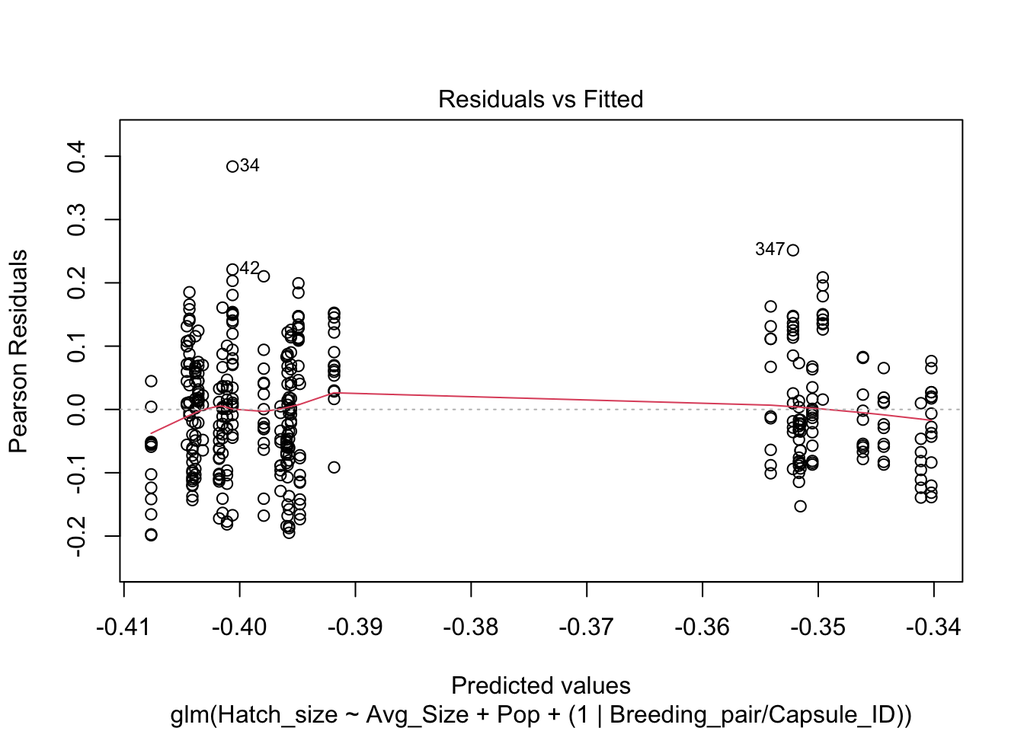

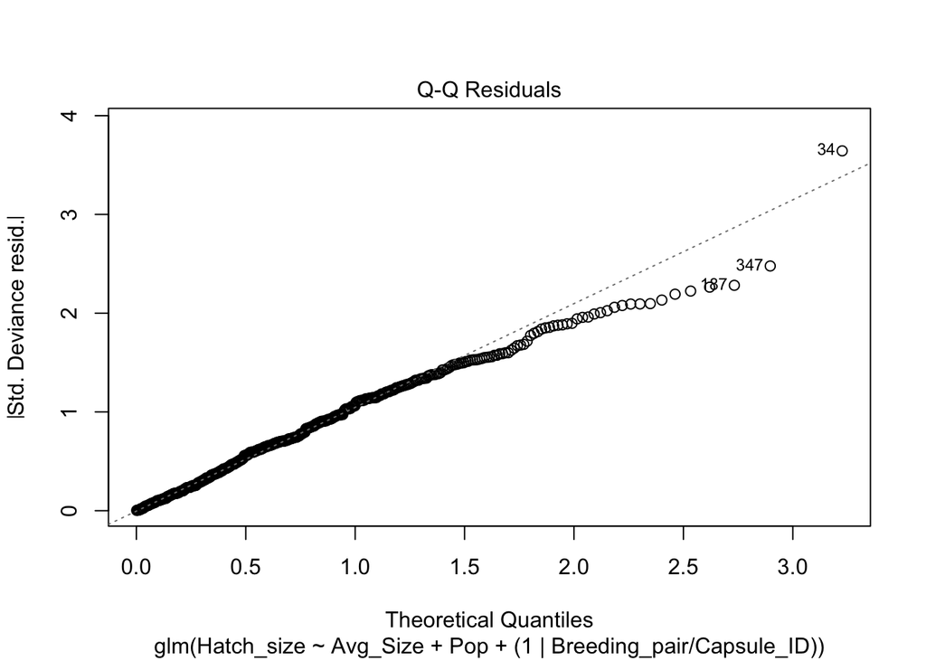

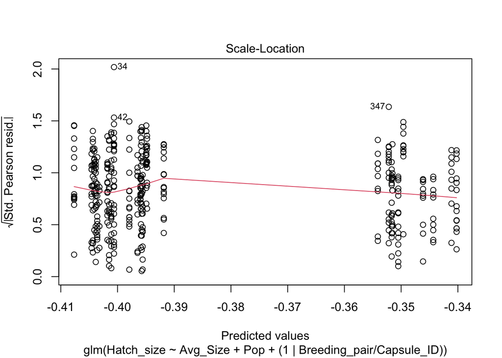

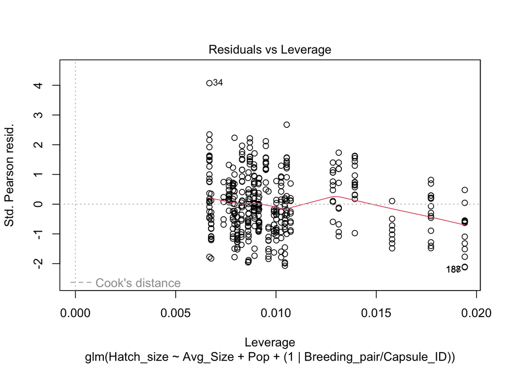

```r
plot(hatch_size_gm)
```

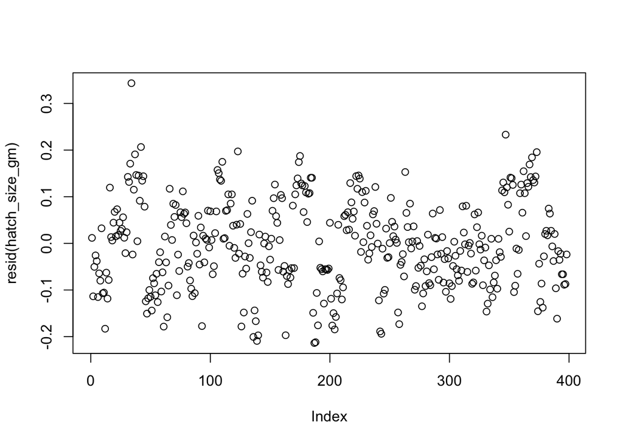

```r
plot(resid(hatch_size_gm))
```

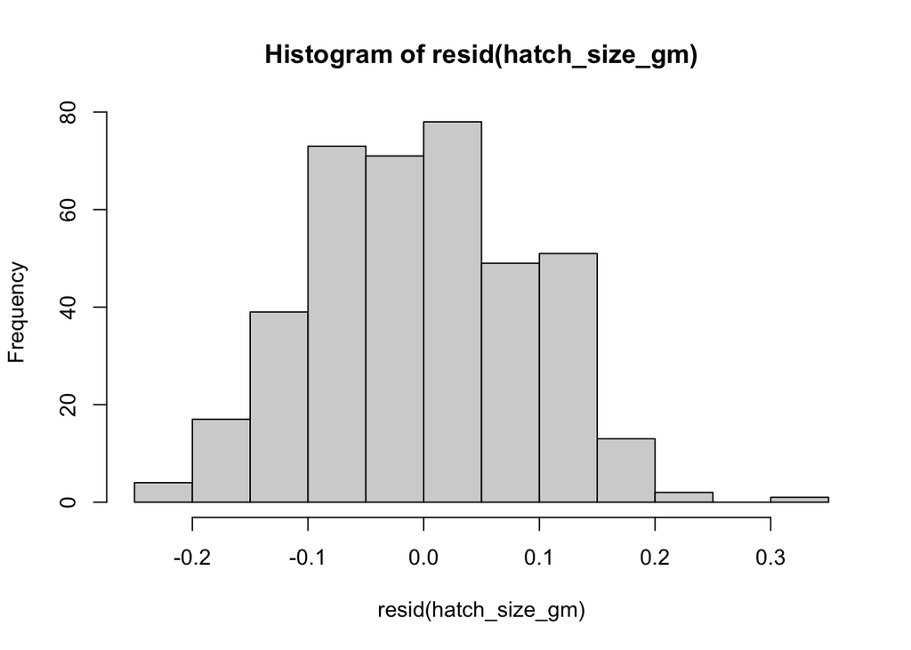

```r
hist(resid(hatch_size_gm))
```

Q-Q plot for model residuals

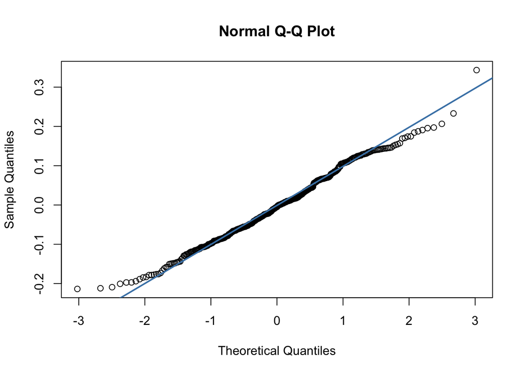

```r
qqnorm(resid(hatch_size_gm))
qqline(resid(hatch_size_gm), col = "steelblue", lwd = 2)
```

### Nurse Eggs

Import data

```r
nurse_eggs <- read.csv("/Users/keiramonuki/Documents/Sanford\ Lab/snail_tank_experiment/nurse_eggs.csv")

head(nurse_eggs)
```

```
##   Breeding_Pair Population Number_hatch Embryo_number     Ratio
## 1         YB_H9         YB     32.00000          36.4  4.400000
## 2         YB_H2         YB     31.00000          47.4 16.400000
## 3        YB_H10         YB     30.33333          39.8  9.466667
## 4        YB_H24         YB     24.33333          38.0 13.666667
## 5        YB_H16         YB     22.50000          33.0 10.500000
## 6        YB_H18         YB     36.33333          42.2  5.866667
```

Remove RP population and one outlier snail (DB_H23)

```r
nurse_eggs %>%
  filter(Population != "RP") %>%
  filter(Breeding_Pair != "DB_H23") -> nurse_eggs
```

Run linear model of nurse egg ratio across populations, and calculate AIC values

```r
nurse_lm <- lm(Ratio ~ Population, data = nurse_eggs)

summary(nurse_lm)
```

```
##
## Call:
## lm(formula = Ratio ~ Population, data = nurse_eggs)
##
## Residuals:
##     Min      1Q  Median      3Q     Max
## -15.407  -4.811  -1.375   5.476  14.793
##
## Coefficients:
##              Estimate Std. Error t value Pr(>|t|)
## (Intercept)    17.553      2.289   7.669 1.86e-08 ***
## PopulationMB   -3.280      3.237  -1.013   0.3193
## PopulationYB   -5.328      3.099  -1.719   0.0962 .
## ---
## Signif. codes:  0 '***' 0.001 '**' 0.01 '*' 0.05 '.' 0.1 ' ' 1
##
## Residual standard error: 7.238 on 29 degrees of freedom
## Multiple R-squared:  0.09302,    Adjusted R-squared:  0.03047
## F-statistic: 1.487 on 2 and 29 DF,  p-value: 0.2428
```

```r
Anova(nurse_lm)
```

```
## Anova Table (Type II tests)
##
## Response: Ratio
##             Sum Sq Df F value Pr(>F)
## Population  155.82  2  1.4871 0.2428
## Residuals  1519.34 29
```

```r
AIC(nurse_lm)
```

```
## [1] 222.3415
```

```r
AICc(nurse_lm)
```

```
## [1] 223.823
```

Plot model residuals to assess model fit

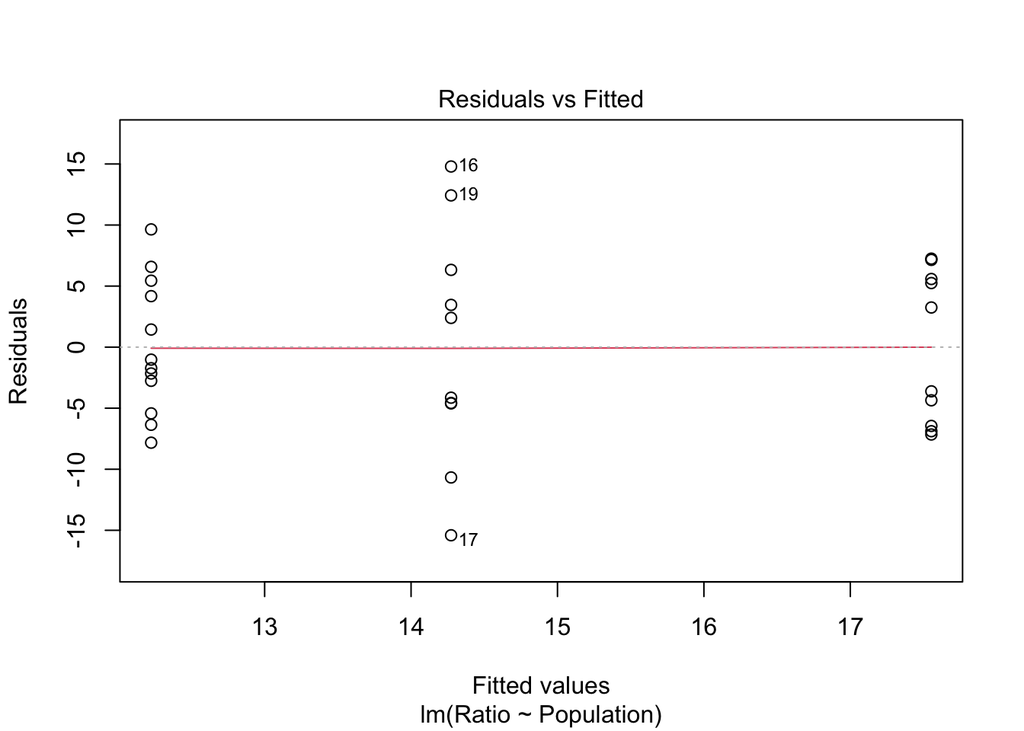

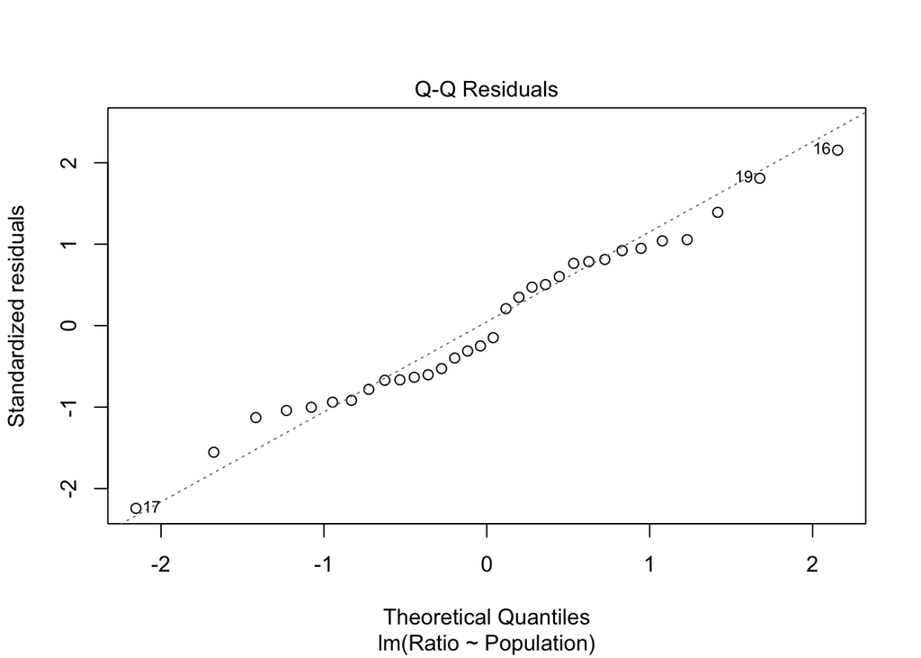

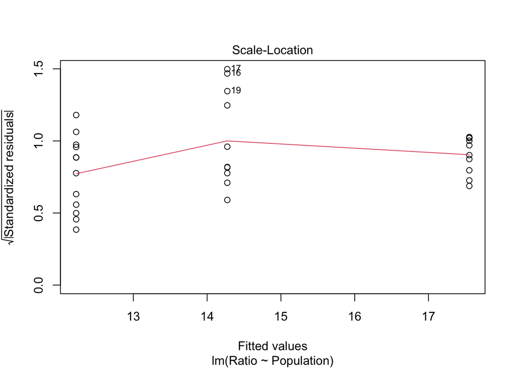

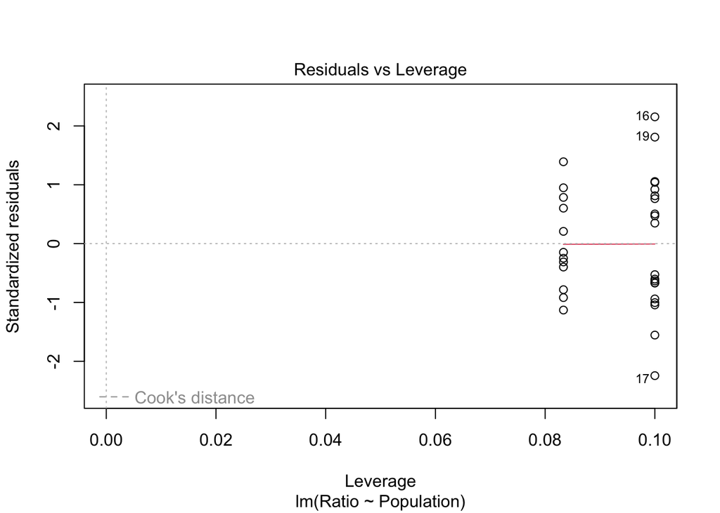

```r
plot(nurse_lm)
```

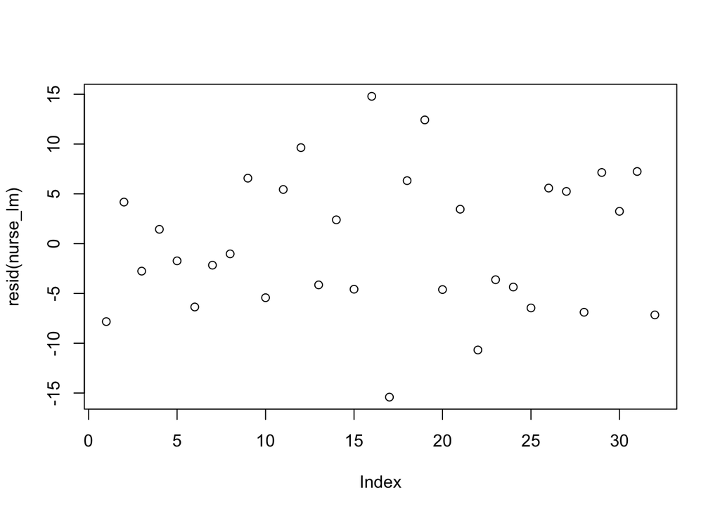

```r
plot(resid(nurse_lm))
```

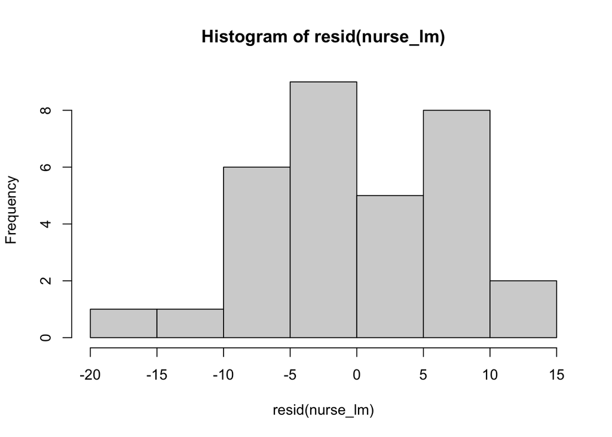

```r
hist(resid(nurse_lm))
```

Q-Q plot of model residuals

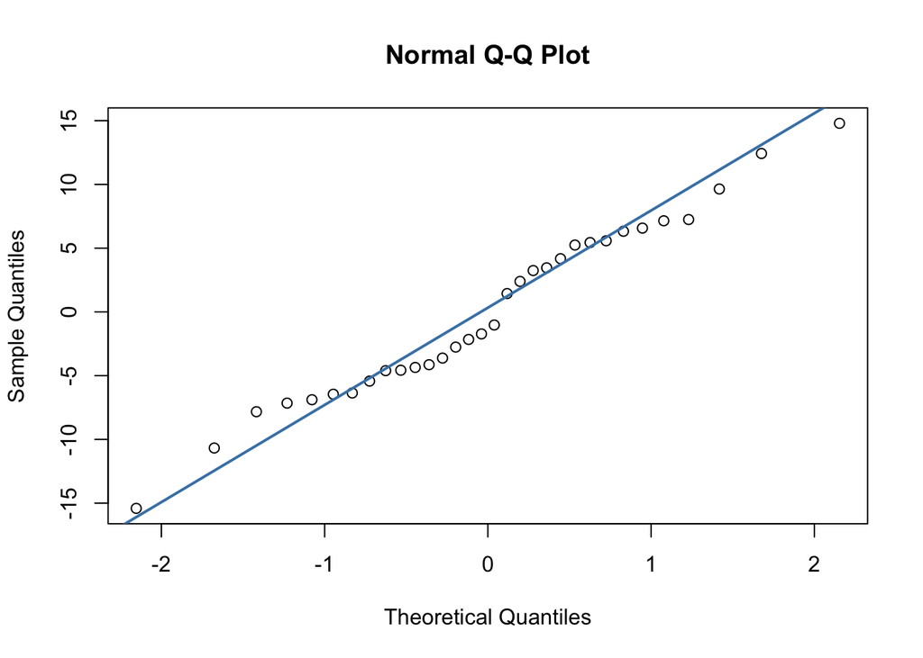

```r
qqnorm(resid(nurse_lm))
qqline(resid(nurse_lm), col = "steelblue", lwd = 2)
```

Isolate model estimates to plot on top of the raw data scatter

```r
emmeans(nurse_lm, "Population", type  = "response", data = nurse_eggs)
```

```
##  Population emmean   SE df lower.CL upper.CL
##  DB           17.6 2.29 29    12.87     22.2
##  MB           14.3 2.29 29     9.59     19.0
##  YB           12.2 2.09 29     7.95     16.5
##
## Confidence level used: 0.95
```

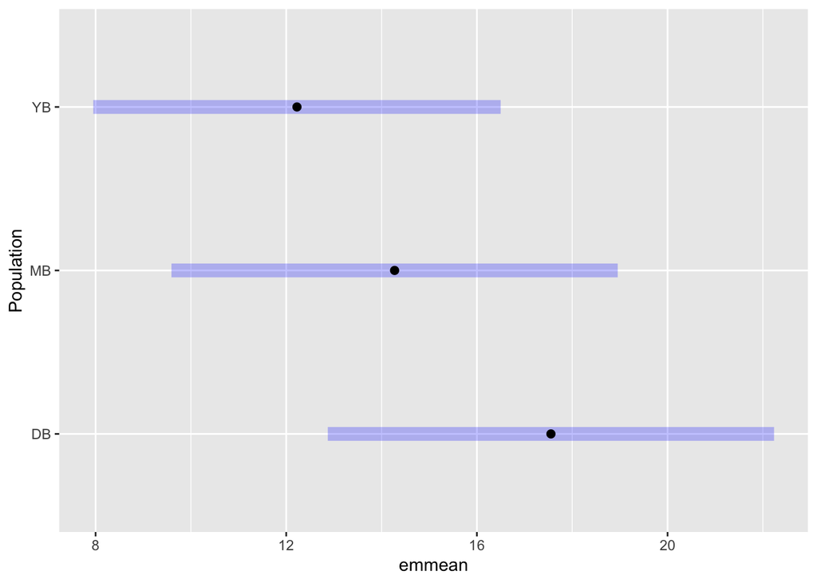

```r
estimates <- emmeans(nurse_lm, "Population", type  = "response", data = nurse_eggs)

plot(estimates)
```

```r
estimates
```

```
##  Population emmean   SE df lower.CL upper.CL
##  DB           17.6 2.29 29    12.87     22.2
##  MB           14.3 2.29 29     9.59     19.0
##  YB           12.2 2.09 29     7.95     16.5
##
## Confidence level used: 0.95
```

Create data frame of model estimates

```r
est <- c(17.6, 14.3, 12.2)
err_high <- c(22.2, 19.0, 16.5)
err_low <- c(12.87, 9.59, 7.95)

nurse_summary <- data.frame(Population = site, Estimate = est, Error_high = err_high, Error_low = err_low)
nurse_summary
```

```
##   Population Estimate Error_high Error_low
## 1         DB     17.6       22.2     12.87
## 2         MB     14.3       19.0      9.59
## 3         YB     12.2       16.5      7.95
```

Plot nurse egg ratios across populations

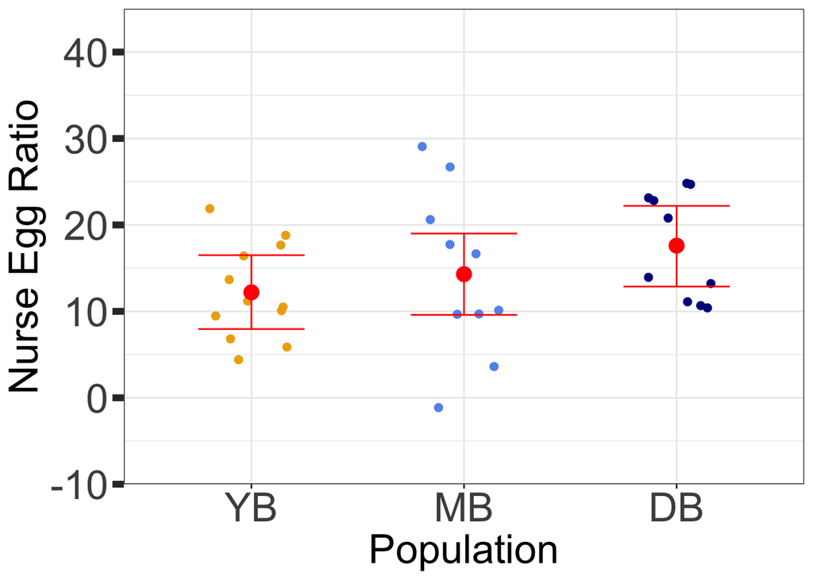

```r
ggplot(nurse_eggs, aes(x = Population, y = Ratio, color = Population)) +
  geom_jitter(aes(x = Population, y = Ratio), position=position_jitter(w=0.2), size = 2) +
  scale_color_manual(values = c("darkgoldenrod2", "cornflowerblue","darkblue")) +
  geom_point(data = nurse_summary, aes(x = Population, y = Estimate), size = 4,  color = "red") +
  geom_errorbar(data = nurse_summary, aes(x = Population, y = Estimate, ymin = Error_low, ymax = Error_high), color = "red", width = 0.5) +
  theme_bw() +
  theme(legend.position = "none",
        axis.title = element_text(size=25),
        axis.text = element_text(size=25),
        axis.ticks.y = element_line(linewidth = 2),
        axis.ticks.length.y = unit(0.25, "cm")) +
  scale_y_continuous(name = "Nurse Egg Ratio", expand = c(0,0), limits = c(-10,45)) +
  xlab("Population") -> nurse_plot

nurse_plot$data$Population <- factor(nurse_plot$data$Population, levels=neworder)

nurse_plot
```

### Growth Rate

Adult snail growth rate in laboratory experiment

Import data

```r
growth <- read.csv("/Users/keiramonuki/Documents/Sanford\ Lab/snail_tank_experiment/growth.csv")

head(growth)
```

```
##   Population Sex Length Cont_ID  ID Treatment     Date Length_Final Date_Final
## 1         YB   M   15.9   YB_H9 141         H 11/15/23         20.6    9/18/24
## 2         YB   F   17.8   YB_H9 181         H 11/15/23         21.0    9/18/24
## 3         YB   F   18.2   YB_H8 210         H 11/15/23         21.3    9/18/24
## 4         YB   M   16.2   YB_H8 292         H 11/15/23         19.1    9/18/24
## 5         YB   M   17.7   YB_H7 259         H 11/15/23         22.0    9/18/24
## 6         YB   F   18.0   YB_H7 481         H 11/15/23         18.7    9/18/24
##   Time      Growth
## 1  308 0.015259740
## 2  308 0.010389610
## 3  308 0.010064935
## 4  308 0.009415584
## 5  308 0.013961039
## 6  308 0.002272727
```

Remove NAs

```r
growth <- na.omit(growth)
```

Remove negative growth rates

```r
growth %>%
  filter(Growth > 0) -> growth
```

Calculate summary statistics (mean, standard deviation, standard error), and save as a data frame

```r
growth %>%
  group_by(Population, Treatment) %>%
  summarise(mean = mean(Growth),
            sd = sd(Growth),
            se = sd(Growth)/sqrt(length(Growth))) -> growth_summary
```

Plot by growth rates by population and treatment

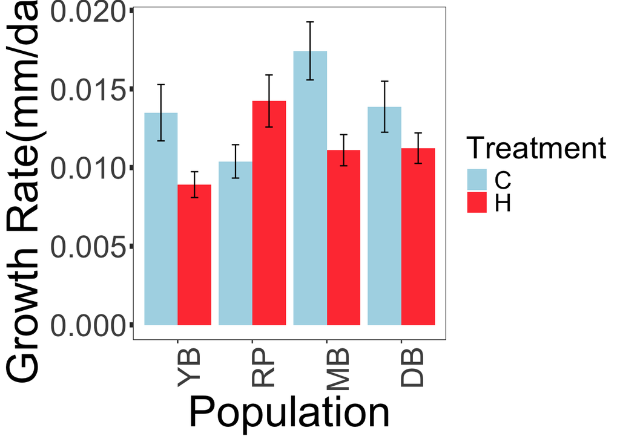

```r
ggplot(growth_summary, aes(x = Population, y = mean, fill = Treatment)) +
  geom_bar(stat = "identity", position = position_dodge()) +
  geom_errorbar(aes(ymin=mean-se, ymax=mean+se), width=.2,
                 position=position_dodge(.9)) +
  scale_fill_manual(values=c('lightblue', 'brown1')) +
  theme_bw() +
  theme(legend.position = "right", panel.grid.minor.y=element_blank(), panel.grid.minor.x=element_blank(),
        legend.title = element_text(size=25),
        legend.text = element_text(size=20),
        panel.grid.major.y=element_blank(),
        panel.grid.major.x=element_blank(),
        axis.text.x = element_text(angle = 90, hjust = 1), axis.title = element_text(size=35),
        plot.title = element_text(size=20, face = "italic"),
        axis.text = element_text(size=25),
        axis.ticks.y = element_line(linewidth = 2)) +
  scale_y_continuous(name = "Growth Rate(mm/day)") +
  xlab("Population") -> growth_plot


neworder = c("YB", "RP", "MB", "DB")

growth_plot$data$Population <- factor(growth_plot$data$Population, levels=neworder)

growth_plot
```

Run a linear model with a interaction between Population * Treatment * Sex and calculate AIC values

```r
growth$Population <- as.factor(growth$Population)

growth_lm2 <- lm(Growth ~ Population*Treatment*Sex, data = growth)

summary(growth_lm2)
```

```
##
## Call:
## lm(formula = Growth ~ Population * Treatment * Sex, data = growth)
##
## Residuals:
##        Min         1Q     Median         3Q        Max
## -0.0163472 -0.0049260 -0.0006754  0.0048020  0.0179417
##
## Coefficients:
##                               Estimate Std. Error t value Pr(>|t|)
## (Intercept)                   0.015935   0.001737   9.172  < 2e-16 ***
## PopulationMB                  0.005950   0.002654   2.242  0.02581 *
## PopulationRP                 -0.004038   0.002283  -1.768  0.07818 .
## PopulationYB                  0.001005   0.002801   0.359  0.72008
## TreatmentH                   -0.003535   0.002283  -1.548  0.12279
## SexM                         -0.004134   0.002457  -1.683  0.09366 .
## PopulationMB:TreatmentH      -0.004998   0.003397  -1.472  0.14236
## PopulationRP:TreatmentH       0.008920   0.003381   2.638  0.00884 **
## PopulationYB:TreatmentH      -0.003518   0.003485  -1.010  0.31360
## PopulationMB:SexM            -0.004801   0.003753  -1.279  0.20198
## PopulationRP:SexM             0.001055   0.003245   0.325  0.74540
## PopulationYB:SexM            -0.002768   0.003962  -0.699  0.48537
## TreatmentH:SexM               0.001806   0.003229   0.559  0.57644
## PopulationMB:TreatmentH:SexM  0.002403   0.004829   0.498  0.61913
## PopulationRP:TreatmentH:SexM -0.005098   0.004831  -1.055  0.29224
## PopulationYB:TreatmentH:SexM  0.003232   0.004911   0.658  0.51100
## ---
## Signif. codes:  0 '***' 0.001 '**' 0.01 '*' 0.05 '.' 0.1 ' ' 1
##
## Residual standard error: 0.006949 on 258 degrees of freedom
## Multiple R-squared:  0.1999, Adjusted R-squared:  0.1534
## F-statistic: 4.297 on 15 and 258 DF,  p-value: 3.827e-07
```

```r
anova(growth_lm2)
```

```
## Analysis of Variance Table
##
## Response: Growth
##                           Df    Sum Sq    Mean Sq F value    Pr(>F)
## Population                 3 0.0003575 0.00011916  2.4673 0.0625956 .
## Treatment                  1 0.0003613 0.00036127  7.4807 0.0066688 **
## Sex                        1 0.0011953 0.00119526 24.7498 1.193e-06 ***
## Population:Treatment       3 0.0008802 0.00029339  6.0751 0.0005208 ***
## Population:Sex             3 0.0001067 0.00003556  0.7364 0.5311642
## Treatment:Sex              1 0.0000560 0.00005597  1.1589 0.2826952
## Population:Treatment:Sex   3 0.0001556 0.00005187  1.0741 0.3605806
## Residuals                258 0.0124598 0.00004829
## ---
## Signif. codes:  0 '***' 0.001 '**' 0.01 '*' 0.05 '.' 0.1 ' ' 1
```

```r
Anova(growth_lm2)
```

```
## Anova Table (Type II tests)
##
## Response: Growth
##                             Sum Sq  Df F value    Pr(>F)
## Population               0.0003374   3  2.3289 0.0749144 .
## Treatment                0.0003708   1  7.6774 0.0059984 **
## Sex                      0.0011946   1 24.7351 1.202e-06 ***
## Population:Treatment     0.0008922   3  6.1578 0.0004664 ***
## Population:Sex           0.0001091   3  0.7530 0.5214886
## Treatment:Sex            0.0000560   1  1.1589 0.2826952
## Population:Treatment:Sex 0.0001556   3  1.0741 0.3605806
## Residuals                0.0124598 258
## ---
## Signif. codes:  0 '***' 0.001 '**' 0.01 '*' 0.05 '.' 0.1 ' ' 1
```

```r
AIC(growth_lm2)
```

```
## [1] -1927.977
```